# Machine learning: Application in Medicine, Exercise 1.2

#1. SVM on the ADI_R items of the Genetic Syndorme Autism data We have seen in the previous Exercise that the contrast between Genetic groups 1 and 5 based on the first two Principle Components, did not achieve a very low error, using Logistic Regression or kNN Here we will use the original 34 Items form the ADI-R questionnaire to classify this contrast, using SVM

```r
# This first part is equal to Exercise 1.1.
# Read the dataset Autism.csv.

dat <- read.csv("Autism.csv")

# select 322 verbal subjects:
dat <- dat[dat$verbal=="verbal",]
head(dat)
```

|  | verbal | ASD | Genetic_Syndrome | Item50 | Item51 | Item57 | item49 | Item62 | Item63 | Item52 | Item53 | Item54 | Item31 | Item55 | Item56 | Item58 | Item59 | Item42 | Item43 | Item44 | Item45 | Item47 | Item48 | Item61 | Item34 | Item35 | Item33 | Item36 | Item37 | … |
| --- | --- | --- | --- | --- | --- | --- | --- | --- | --- | --- | --- | --- | --- | --- | --- | --- | --- | --- | --- | --- | --- | --- | --- | --- | --- | --- | --- | --- | --- | --- |
| 1 | verbal | yes | SMC | 1 | 1 | 2 | 2 | 1 | 2 | 2 | 0 | 0 | 1 | 0 | 2 | 2 | 0 | 2 | 2 | 2 | 2 | 1 | 1 | 1 | 1 | 1 | 2 | 2 | 0 | … |
| 4 | verbal | yes | SMC | 0 | 0 | 1 | 2 | 0 | 0 | 1 | 1 | 0 | 2 | 0 | 1 | 1 | 0 | 2 | 2 | 0 | 0 | 1 | 1 | 0 | 1 | 0 | 2 | 1 | 0 | … |
| 5 | verbal | yes | SMC | 2 | 1 | 0 | 2 | 0 | 0 | 1 | 0 | 0 | 0 | 0 | 2 | 0 | 0 | 2 | 2 | 2 | 2 | 2 | 2 | 1 | 2 | 2 | 2 | 0 | 0 | … |
| 6 | verbal | yes | SMC | 1 | 1 | 2 | 2 | 2 | 2 | 2 | 1 | 2 | 2 | 2 | 2 | 0 | 0 | 2 | 2 | 0 | 2 | 2 | 2 | 2 | 2 | 1 | 2 | 0 | 0 | … |
| 7 | verbal | no | SMC | 0 | 1 | 0 | 0 | 0 | 2 | 1 | 1 | 0 | 0 | 0 | 0 | 0 | 2 | 1 | 0 | 0 | 0 | 0 | 0 | 0 | 1 | 1 | 0 | 1 | 0 | … |
| 9 | verbal | yes | SMC | 1 | 2 | 2 | 2 | 2 | 2 | 2 | 1 | 2 | 2 | 2 | 2 | 0 | 0 | 2 | 1 | 1 | 2 | 2 | 2 | 1 | 1 | 2 | 0 | 2 | 0 | … |

```r
# make separate object for ADI-R items
Items <- dat[,-(1:3)]
# and version of the data with only Items and the genetic group variable
dat1 <- dat[,-(1:2)]
# restrict the data to two groups: 1 and 5, use a logical selection vector
select15 <- dat1$Genetic_Syndrome %in% levels(dat1$Genetic_Syndrome)[c(1,5)]
table(dat[select15,]$Genetic_Syndrome)
```

```
22q11DS    Down      PW     SMC     TSC     XXY
     90       0       0       0      50       0
```

We will use the package caret, which contains the function train, to train classifiers. There are several variants of svm available in caret

```r
library(caret)
# if needed, install the boot package:
# install.packages("caret")
# Fit SVM with linear kernel, default Cost parameter
# first define a traincontrol object, that set the method for crossvalidation, and the output, including predicted probabilities
ctrl <- trainControl(method = "LOOCV", savePred=T,classProbs=TRUE)
svm.fit <- train(x=Items[select15,],
               y=factor(dat[select15,]$Genetic_Syndrome,labels=c("group1","group5")),
                 method="svmLinear",
                 preProcess="scale",
                 trControl = ctrl)
names(svm.fit)
```

```
 [1] "method"       "modelInfo"    "modelType"    "results"
 [5] "pred"         "bestTune"     "call"         "dots"
 [9] "metric"       "control"      "finalModel"   "preProcess"
[13] "trainingData" "resample"     "resampledCM"  "perfNames"
[17] "maximize"     "yLimits"      "times"        "levels"
```

```r
svm.fit$results
```

|  | C | Accuracy | Kappa |
| --- | --- | --- | --- |
| 1 | 1 | 0.8571429 | 0.6744186 |

```r
svm.fit$bestTune
```

|  | C |
| --- | --- |
| 1 | 1 |

The Cost parameter C was set to a default value of 1. In data that are not completely separated, the cost parameters should be optimised by tuning. The train function can do this by means of cross validation

```r
# Fit SVM with linear kernel, tune Cost parameter
ctrl <- trainControl(method = "LOOCV", savePred=T)
svm.fit.tuned <- train(x=Items[select15,],
              y=factor(dat[select15,]$Genetic_Syndrome,labels=c("group1","group5")),
                    method="svmLinear",
                    preProcess="scale",
                    trControl = ctrl, tuneGrid = data.frame(C=c(0.1,0.2,0.3,0.4,0.5,0.6,0.8,1) ) )
svm.fit.tuned$results
```

|  | C | Accuracy | Kappa |
| --- | --- | --- | --- |
| 1 | 0.1 | 0.8500000 | 0.6466346 |
| 2 | 0.2 | 0.8357143 | 0.6238318 |
| 3 | 0.3 | 0.8857143 | 0.7395349 |
| 4 | 0.4 | 0.8785714 | 0.7245370 |
| 5 | 0.5 | 0.8785714 | 0.7270642 |
| 6 | 0.6 | 0.8642857 | 0.6921296 |
| 7 | 0.8 | 0.8571429 | 0.6803653 |
| 8 | 1.0 | 0.8500000 | 0.6659091 |

```r
svm.fit.tuned$bestTune
```

|  | C |
| --- | --- |
| 3 | 0.3 |

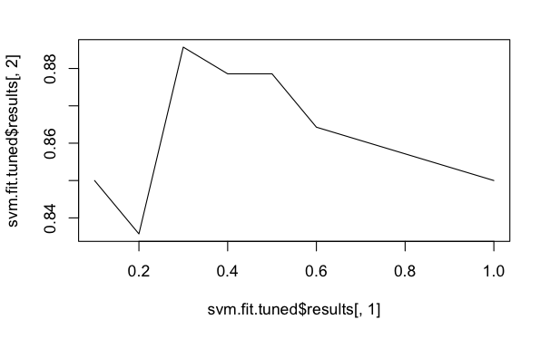

```r
plot(svm.fit.tuned$results[,1],svm.fit.tuned$results[,2],type='l')
```

We see that a higher accuracy is obtained by optimising the Cost paramater.

Q1: try to improve further on the accuracy, by changing the linear kernel into a radial kernel (“svmRadial”)

```r
cRange <- c(1,2,5,10)
sigmaRange <- c(0.05,0.01,0.02)
svm.fit.tuned2 <- train(x=Items[select15,],y=factor(dat[select15,]$Genetic_Syndrome),method="svmRadial",preProcess="scale",trControl = ctrl,tuneGrid=expand.grid(C=cRange,sigma=sigmaRange) )
svm.fit.tuned2$results
```

|  | sigma | C | Accuracy | Kappa |
| --- | --- | --- | --- | --- |
| 1 | 0.01 | 1 | 0.8428571 | 0.6206897 |
| 2 | 0.01 | 2 | 0.8642857 | 0.6771845 |
| 3 | 0.01 | 5 | 0.9000000 | 0.7677725 |
| 4 | 0.01 | 10 | 0.8785714 | 0.7245370 |
| 5 | 0.02 | 1 | 0.8571429 | 0.6585366 |
| 6 | 0.02 | 2 | 0.9000000 | 0.7677725 |
| 7 | 0.02 | 5 | 0.8928571 | 0.7546729 |
| 8 | 0.02 | 10 | 0.8714286 | 0.7096774 |
| 9 | 0.05 | 1 | 0.8500000 | 0.6432039 |
| 10 | 0.05 | 2 | 0.8785714 | 0.7166667 |

[output cut: 2 more lines]

```r
matrix(svm.fit.tuned2$results$Accuracy,nrow=length(cRange))
```

```
          [,1]      [,2]      [,3]
[1,] 0.8428571 0.8571429 0.8500000
[2,] 0.8642857 0.9000000 0.8785714
[3,] 0.9000000 0.8928571 0.8571429
[4,] 0.8785714 0.8714286 0.8714286
```

We see that an even higher accuracy is obtained by specifc combinations of sigma, and C.

Q2: # Find the predicted probabilities for belonging to group 5 from SVM with linear kernel, with the optimal Cost parameter.

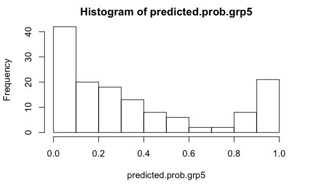

```r
predicted.prob.grp5 <- svm.fit.tuned$pred[svm.fit.tuned$pred[,"C"]==as.numeric(svm.fit.tuned$bestTune),
                   "group5"]
hist(predicted.prob.grp5)
```

Calibration plot

```
         Dxy      C (ROC)           R2            D     D:Chi-sq
 0.828000000  0.914000000  0.640669658  0.621489175 88.008484523
         D:p            U     U:Chi-sq          U:p            Q
          NA -0.009681011  0.644658411  0.724459655  0.631170187
       Brier    Intercept        Slope         Emax          E90
 0.101852407  0.082615498  1.161561153  0.073140922  0.062201885
        Eavg          S:z          S:p
 0.035170883 -0.993771224  0.320334259
```

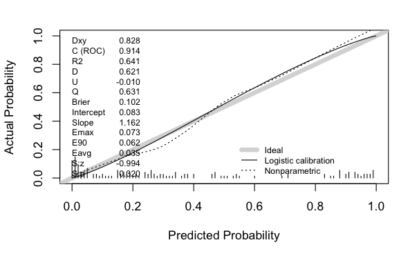

```r
require(rms)
val.prob(predicted.prob.grp5,
         as.numeric(factor(dat[select15,]$Genetic_Syndrome))-1)
```